# Experiments with groups of stations: perc_lake quantiles

FBK

9 januar 2017

## QS

[1] “QS” [1] 2 [1] 1 5 6 7 8 9 10 11 12 16 19 21 22 23 24 25 26 [18] 29 30 31 32 41 42 45 47 63 65 66 67 92 96 103 107 112 [35] 119 121 123 126 142 157 159 163 165 166 167 168 169 171 175 179 186 [52] 188 196 198 200 201 204 208 209 212 224 230 235 237 238 240 251 252 [69] 262 279 287 291 [1] “done printint”

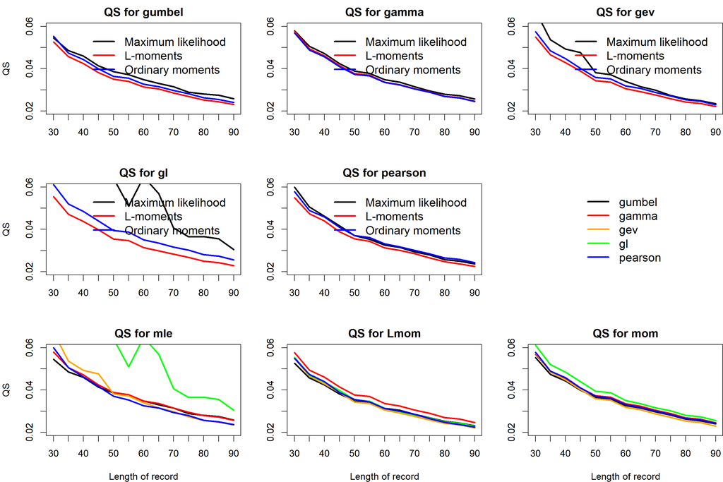

[1] “QS” [1] 2 [1] 2 4 13 14 17 27 28 34 35 37 40 44 46 48 49 50 56 [18] 59 60 61 62 69 74 91 97 101 102 104 105 108 109 110 113 120 [35] 122 125 127 128 133 141 143 148 150 152 153 154 160 164 173 174 189 [52] 190 199 202 213 216 227 236 239 243 245 256 260 274 281 285 288 289 [69] 290 302 [1] “done printint”

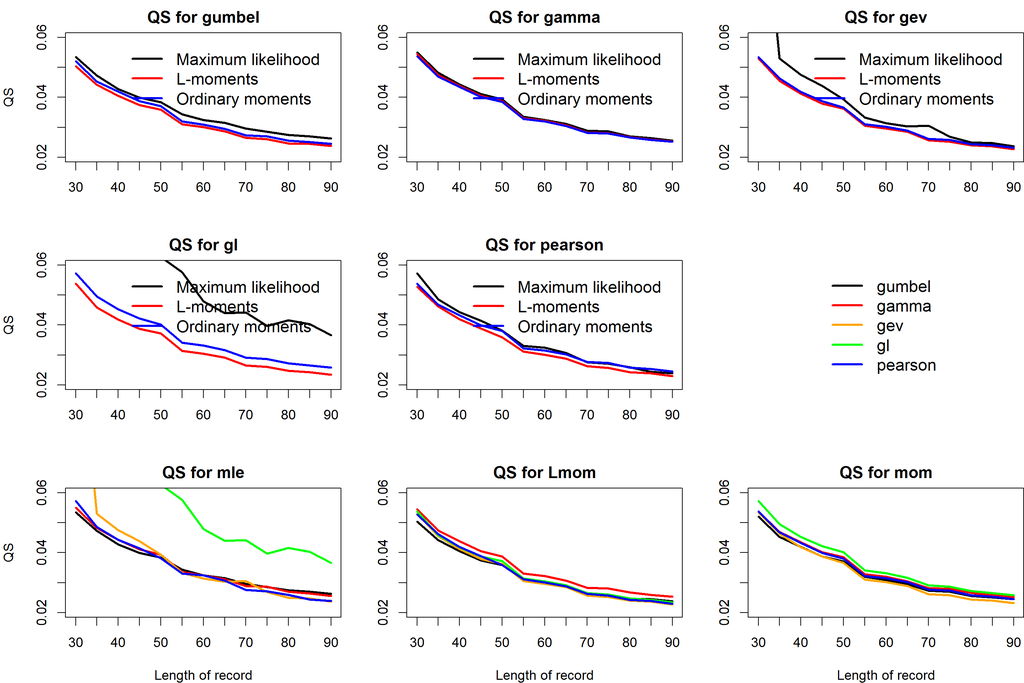

[1] “QS” [1] 2 [1] 15 18 20 33 36 39 43 52 53 54 55 58 71 72 75 80 84 [18] 86 89 90 93 98 100 111 115 116 117 118 130 134 136 138 139 140 [35] 144 155 158 161 170 177 178 182 183 191 197 207 211 214 223 226 229 [52] 231 234 241 242 244 246 247 249 255 257 261 268 272 275 276 277 280 [69] 283 295 300 [1] “done printint”

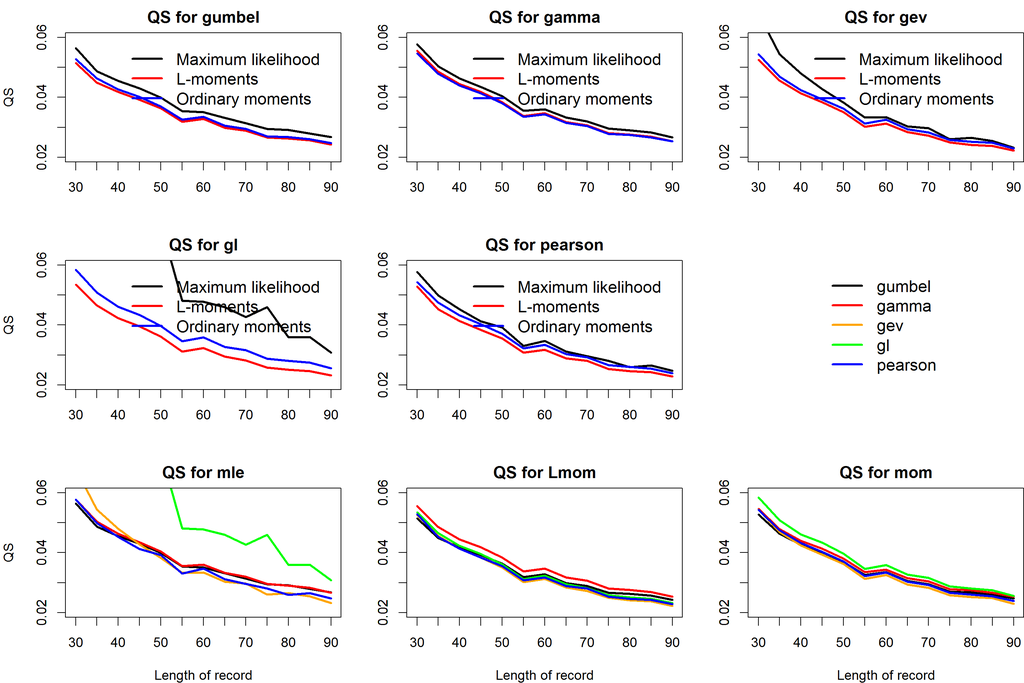

[1] “QS” [1] 2 [1] 38 51 57 68 70 76 77 78 79 81 82 83 85 87 88 94 95 [18] 99 106 114 129 131 132 135 137 145 146 147 149 151 156 172 176 180 [35] 181 185 187 192 194 195 203 205 215 217 218 219 220 221 222 225 228 [52] 233 253 254 258 259 263 264 269 270 271 273 278 282 292 293 298 303 [69] 304 305 306 [1] “done printint”

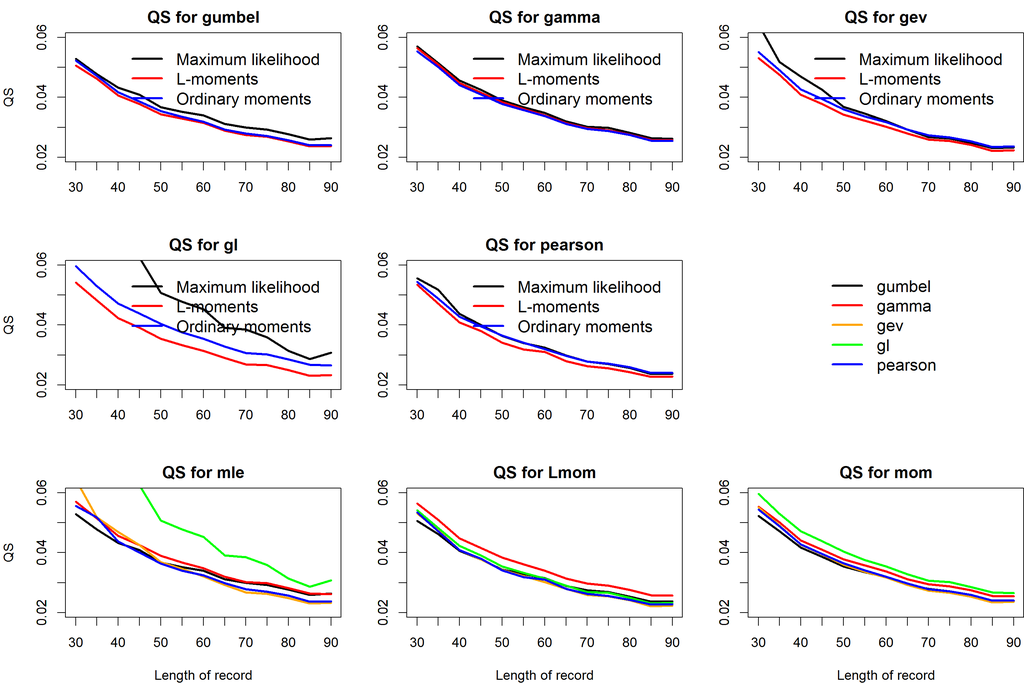

## BS

[1] “BS” [1] 2 [1] 1 5 6 7 8 9 10 11 12 16 19 21 22 23 24 25 26 [18] 29 30 31 32 41 42 45 47 63 65 66 67 92 96 103 107 112 [35] 119 121 123 126 142 157 159 163 165 166 167 168 169 171 175 179 186 [52] 188 196 198 200 201 204 208 209 212 224 230 235 237 238 240 251 252 [69] 262 279 287 291 [1] “done printint”

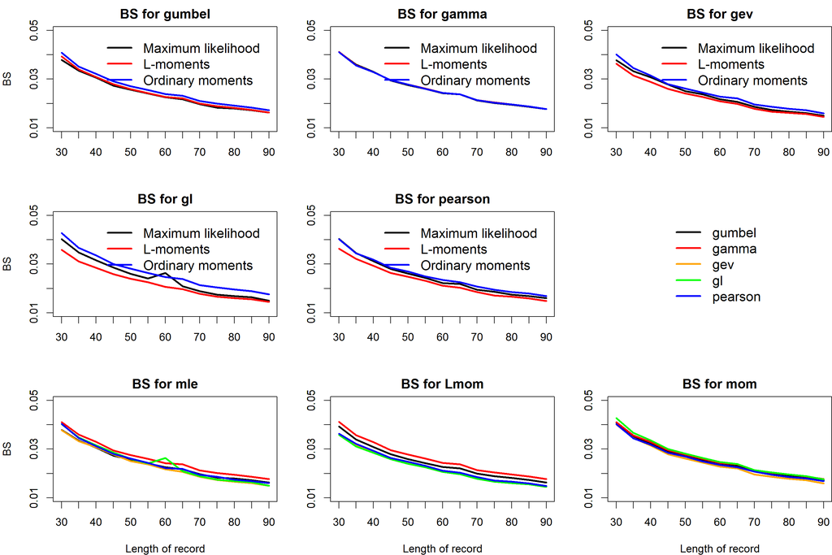

[1] “BS” [1] 2 [1] 2 4 13 14 17 27 28 34 35 37 40 44 46 48 49 50 56 [18] 59 60 61 62 69 74 91 97 101 102 104 105 108 109 110 113 120 [35] 122 125 127 128 133 141 143 148 150 152 153 154 160 164 173 174 189 [52] 190 199 202 213 216 227 236 239 243 245 256 260 274 281 285 288 289 [69] 290 302 [1] “done printint”

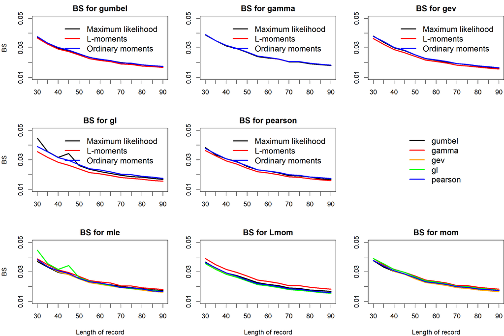

[1] “BS” [1] 2 [1] 15 18 20 33 36 39 43 52 53 54 55 58 71 72 75 80 84 [18] 86 89 90 93 98 100 111 115 116 117 118 130 134 136 138 139 140 [35] 144 155 158 161 170 177 178 182 183 191 197 207 211 214 223 226 229 [52] 231 234 241 242 244 246 247 249 255 257 261 268 272 275 276 277 280 [69] 283 295 300 [1] “done printint”

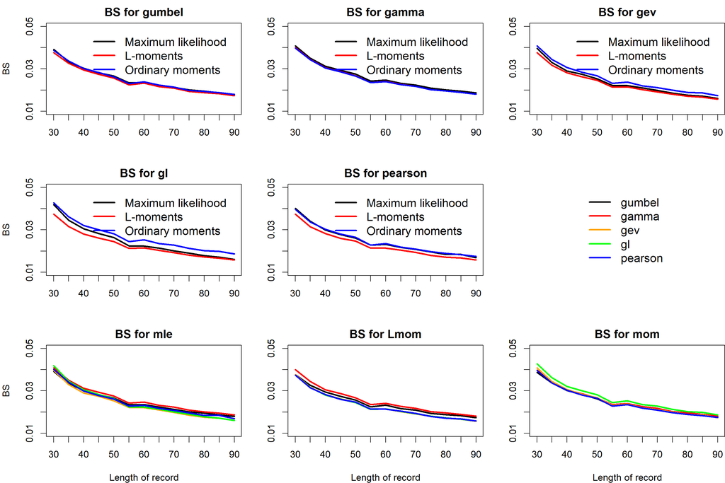

[1] “BS” [1] 2 [1] 38 51 57 68 70 76 77 78 79 81 82 83 85 87 88 94 95 [18] 99 106 114 129 131 132 135 137 145 146 147 149 151 156 172 176 180 [35] 181 185 187 192 194 195 203 205 215 217 218 219 220 221 222 225 228 [52] 233 253 254 258 259 263 264 269 270 271 273 278 282 292 293 298 303 [69] 304 305 306 [1] “done printint”

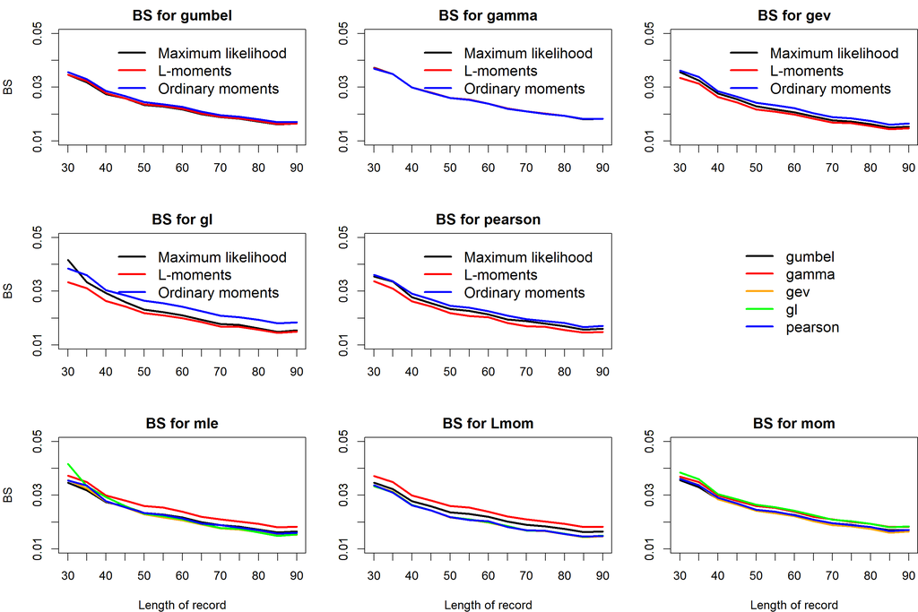

## Return levels

#### RL 10y

[1] “r.levels” [1] 10 [1] 1 5 6 7 8 9 10 11 12 16 19 21 22 23 24 25 26 [18] 29 30 31 32 41 42 45 47 63 65 66 67 92 96 103 107 112 [35] 119 121 123 126 142 157 159 163 165 166 167 168 169 171 175 179 186 [52] 188 196 198 200 201 204 208 209 212 224 230 235 237 238 240 251 252 [69] 262 279 287 291 [1] “done printint”

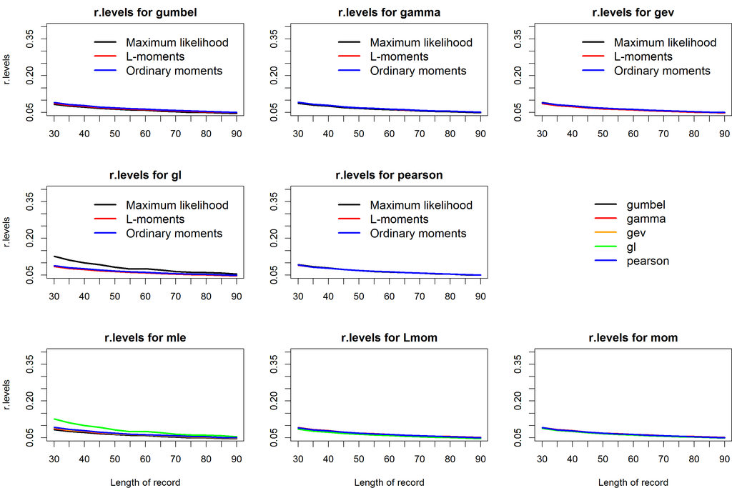

[1] “r.levels” [1] 10 [1] 2 4 13 14 17 27 28 34 35 37 40 44 46 48 49 50 56 [18] 59 60 61 62 69 74 91 97 101 102 104 105 108 109 110 113 120 [35] 122 125 127 128 133 141 143 148 150 152 153 154 160 164 173 174 189 [52] 190 199 202 213 216 227 236 239 243 245 256 260 274 281 285 288 289 [69] 290 302 [1] “done printint”

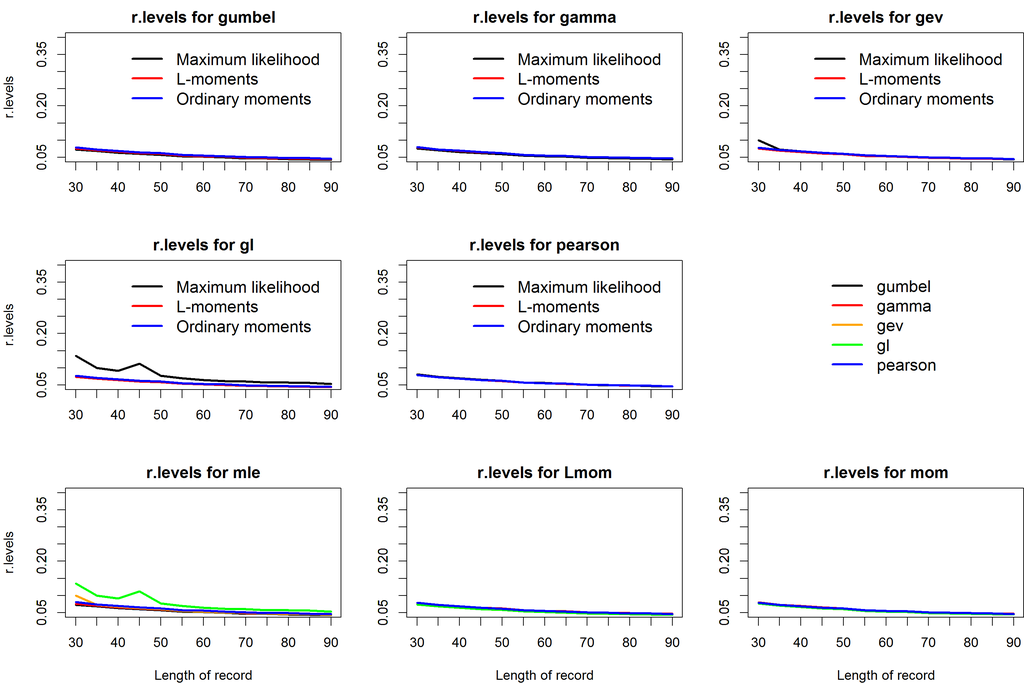

[1] “r.levels” [1] 10 [1] 15 18 20 33 36 39 43 52 53 54 55 58 71 72 75 80 84 [18] 86 89 90 93 98 100 111 115 116 117 118 130 134 136 138 139 140 [35] 144 155 158 161 170 177 178 182 183 191 197 207 211 214 223 226 229 [52] 231 234 241 242 244 246 247 249 255 257 261 268 272 275 276 277 280 [69] 283 295 300 [1] “done printint”

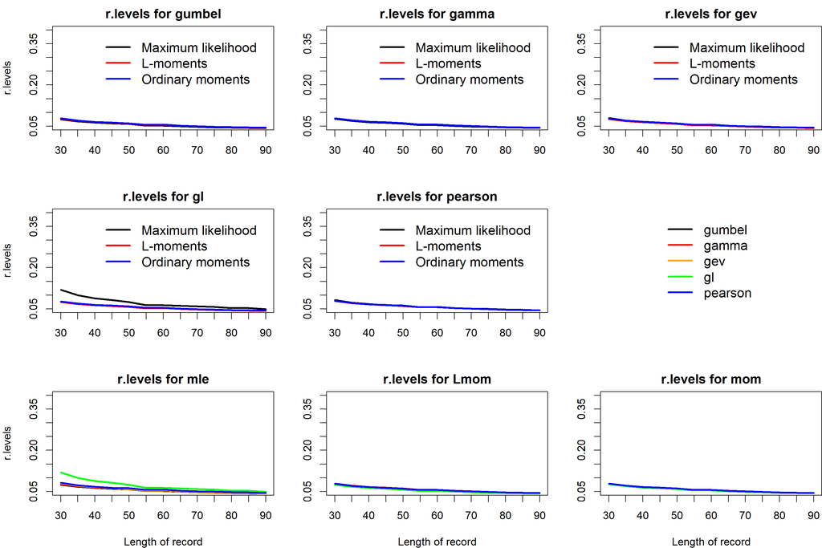

[1] “r.levels” [1] 10 [1] 38 51 57 68 70 76 77 78 79 81 82 83 85 87 88 94 95 [18] 99 106 114 129 131 132 135 137 145 146 147 149 151 156 172 176 180 [35] 181 185 187 192 194 195 203 205 215 217 218 219 220 221 222 225 228 [52] 233 253 254 258 259 263 264 269 270 271 273 278 282 292 293 298 303 [69] 304 305 306 [1] “done printint”

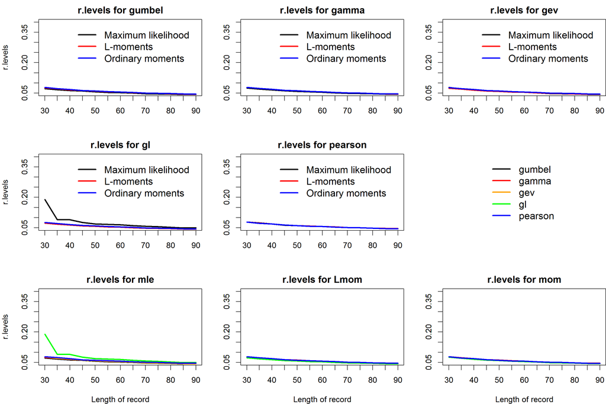

#### RL 100y

[1] “r.levels” [1] 100 [1] 1 5 6 7 8 9 10 11 12 16 19 21 22 23 24 25 26 [18] 29 30 31 32 41 42 45 47 63 65 66 67 92 96 103 107 112 [35] 119 121 123 126 142 157 159 163 165 166 167 168 169 171 175 179 186 [52] 188 196 198 200 201 204 208 209 212 224 230 235 237 238 240 251 252 [69] 262 279 287 291 [1] “done printint”

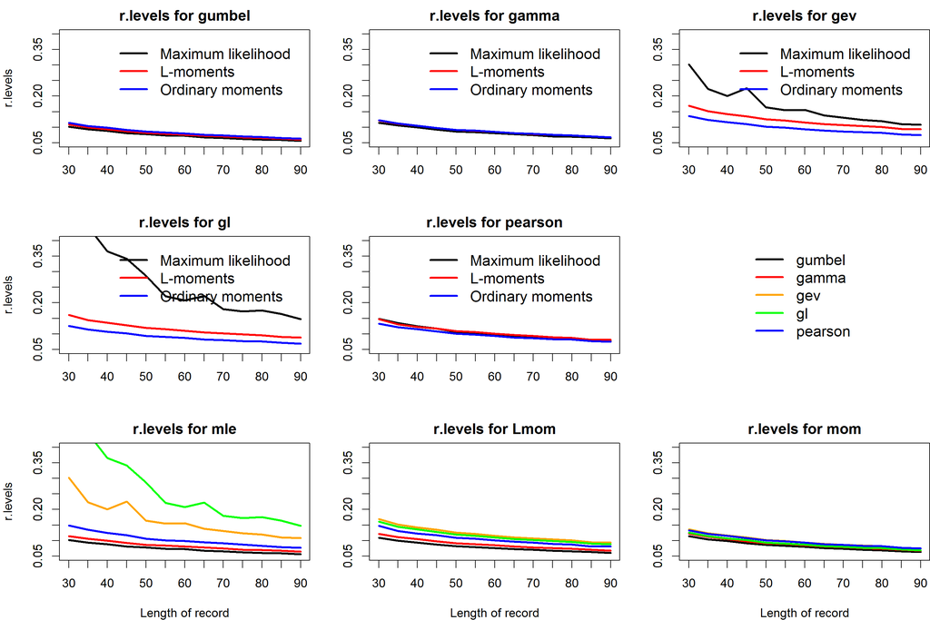

[1] “r.levels” [1] 100 [1] 2 4 13 14 17 27 28 34 35 37 40 44 46 48 49 50 56 [18] 59 60 61 62 69 74 91 97 101 102 104 105 108 109 110 113 120 [35] 122 125 127 128 133 141 143 148 150 152 153 154 160 164 173 174 189 [52] 190 199 202 213 216 227 236 239 243 245 256 260 274 281 285 288 289 [69] 290 302 [1] “done printint”

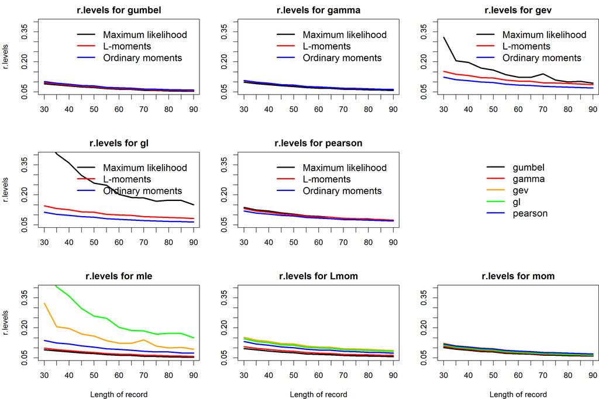

[1] “r.levels” [1] 100 [1] 15 18 20 33 36 39 43 52 53 54 55 58 71 72 75 80 84 [18] 86 89 90 93 98 100 111 115 116 117 118 130 134 136 138 139 140 [35] 144 155 158 161 170 177 178 182 183 191 197 207 211 214 223 226 229 [52] 231 234 241 242 244 246 247 249 255 257 261 268 272 275 276 277 280 [69] 283 295 300 [1] “done printint”

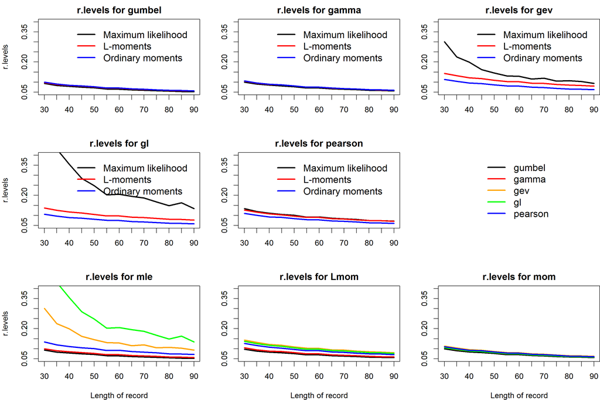

[1] “r.levels” [1] 100 [1] 38 51 57 68 70 76 77 78 79 81 82 83 85 87 88 94 95 [18] 99 106 114 129 131 132 135 137 145 146 147 149 151 156 172 176 180 [35] 181 185 187 192 194 195 203 205 215 217 218 219 220 221 222 225 228 [52] 233 253 254 258 259 263 264 269 270 271 273 278 282 292 293 298 303 [69] 304 305 306 [1] “done printint”

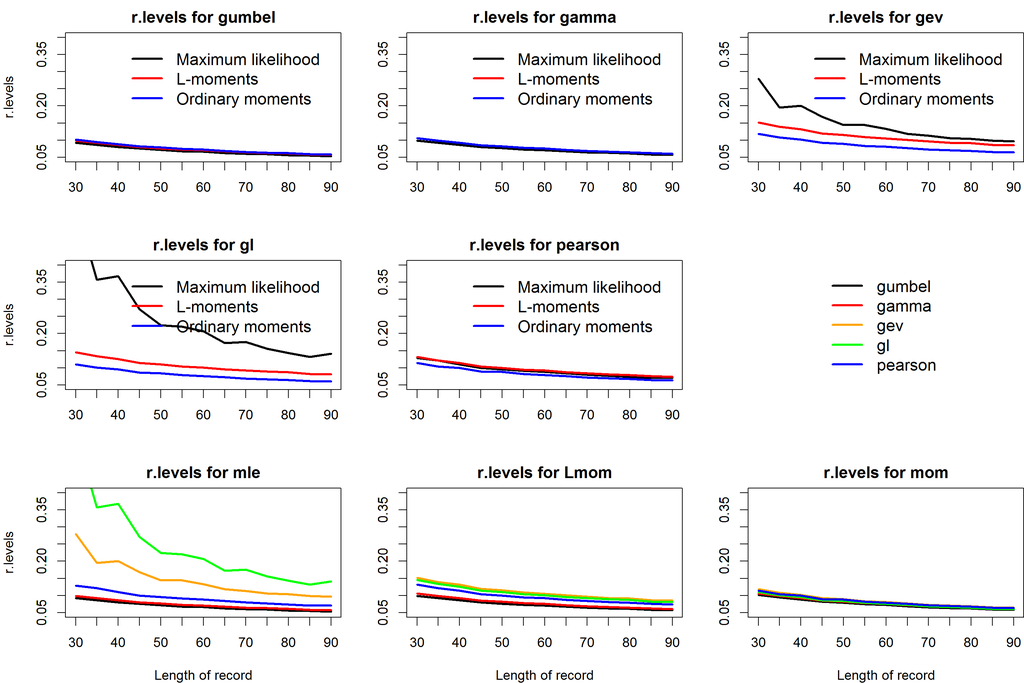

#### RL 200y

[1] “r.levels” [1] 200 [1] 1 5 6 7 8 9 10 11 12 16 19 21 22 23 24 25 26 [18] 29 30 31 32 41 42 45 47 63 65 66 67 92 96 103 107 112 [35] 119 121 123 126 142 157 159 163 165 166 167 168 169 171 175 179 186 [52] 188 196 198 200 201 204 208 209 212 224 230 235 237 238 240 251 252 [69] 262 279 287 291 [1] “done printint”

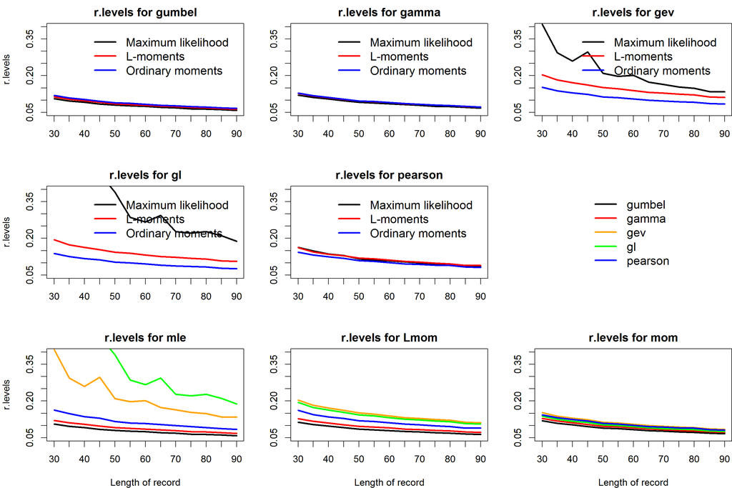

[1] “r.levels” [1] 200 [1] 2 4 13 14 17 27 28 34 35 37 40 44 46 48 49 50 56 [18] 59 60 61 62 69 74 91 97 101 102 104 105 108 109 110 113 120 [35] 122 125 127 128 133 141 143 148 150 152 153 154 160 164 173 174 189 [52] 190 199 202 213 216 227 236 239 243 245 256 260 274 281 285 288 289 [69] 290 302 [1] “done printint”

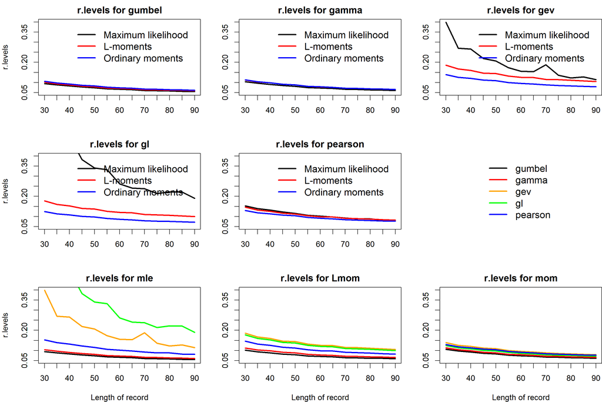

[1] “r.levels” [1] 200 [1] 15 18 20 33 36 39 43 52 53 54 55 58 71 72 75 80 84 [18] 86 89 90 93 98 100 111 115 116 117 118 130 134 136 138 139 140 [35] 144 155 158 161 170 177 178 182 183 191 197 207 211 214 223 226 229 [52] 231 234 241 242 244 246 247 249 255 257 261 268 272 275 276 277 280 [69] 283 295 300 [1] “done printint”

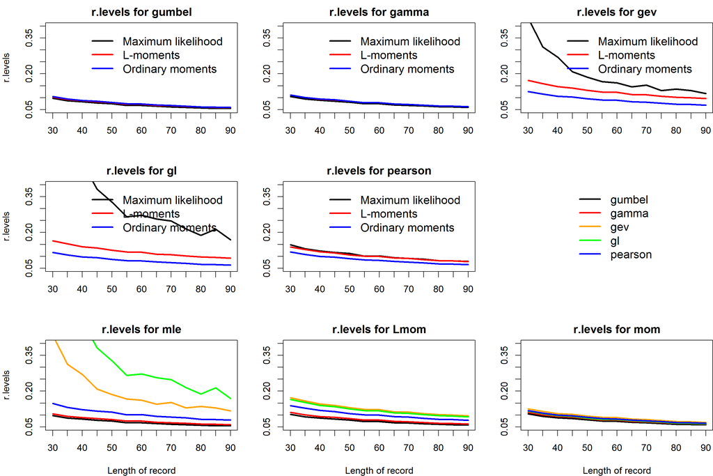

[1] “r.levels” [1] 200 [1] 38 51 57 68 70 76 77 78 79 81 82 83 85 87 88 94 95 [18] 99 106 114 129 131 132 135 137 145 146 147 149 151 156 172 176 180 [35] 181 185 187 192 194 195 203 205 215 217 218 219 220 221 222 225 228 [52] 233 253 254 258 259 263 264 269 270 271 273 278 282 292 293 298 303 [69] 304 305 306 [1] “done printint”

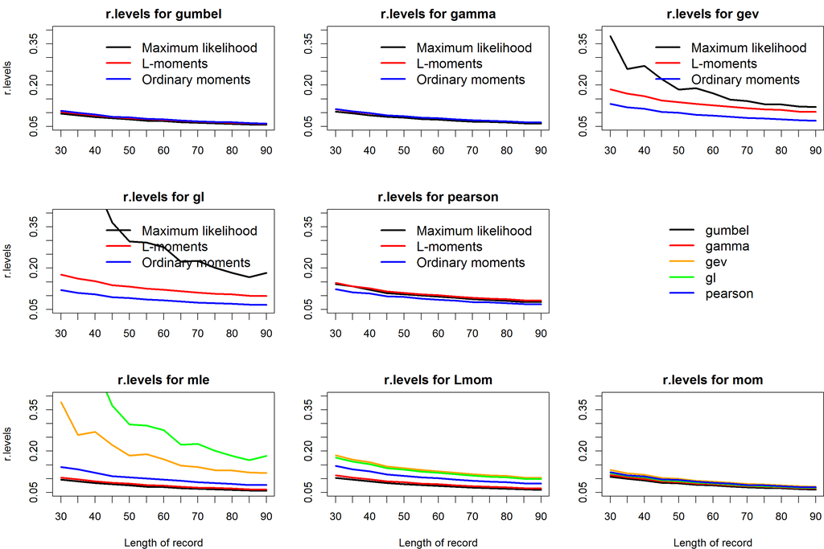

## KS

[1] 1 5 6 7 8 9 10 11 12 16 19 21 22 23 24 25 26 [18] 29 30 31 32 41 42 45 47 63 65 66 67 92 96 103 107 112 [35] 119 121 123 126 142 157 159 163 165 166 167 168 169 171 175 179 186 [52] 188 196 198 200 201 204 208 209 212 224 230 235 237 238 240 251 252 [69] 262 279 287 291 [1] “entered the plotting function” [1] 30 [1] 150

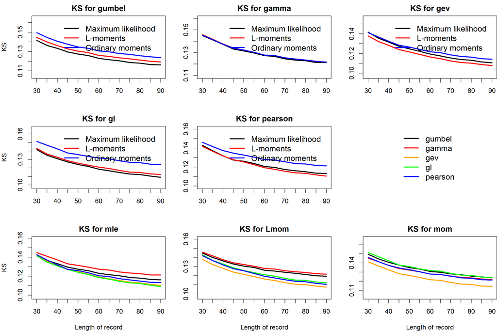

[1] 2 4 13 14 17 27 28 34 35 37 40 44 46 48 49 50 56 [18] 59 60 61 62 69 74 91 97 101 102 104 105 108 109 110 113 120 [35] 122 125 127 128 133 141 143 148 150 152 153 154 160 164 173 174 189 [52] 190 199 202 213 216 227 236 239 243 245 256 260 274 281 285 288 289 [69] 290 302 [1] “entered the plotting function” [1] 30 [1] 150

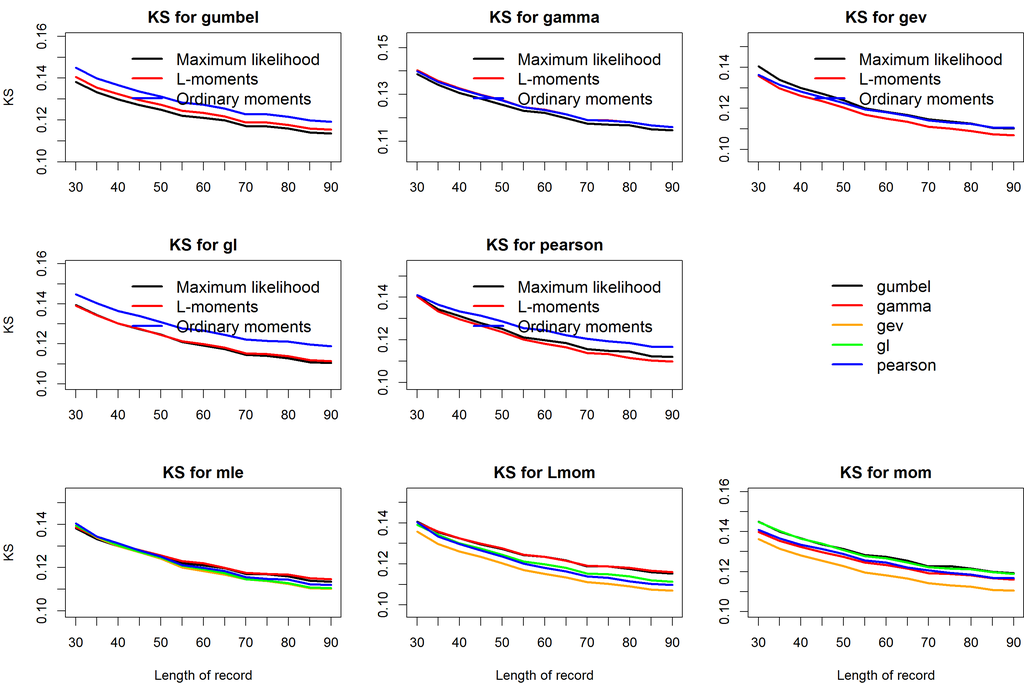

[1] 15 18 20 33 36 39 43 52 53 54 55 58 71 72 75 80 84 [18] 86 89 90 93 98 100 111 115 116 117 118 130 134 136 138 139 140 [35] 144 155 158 161 170 177 178 182 183 191 197 207 211 214 223 226 229 [52] 231 234 241 242 244 246 247 249 255 257 261 268 272 275 276 277 280 [69] 283 295 300 [1] “entered the plotting function” [1] 30 [1] 150

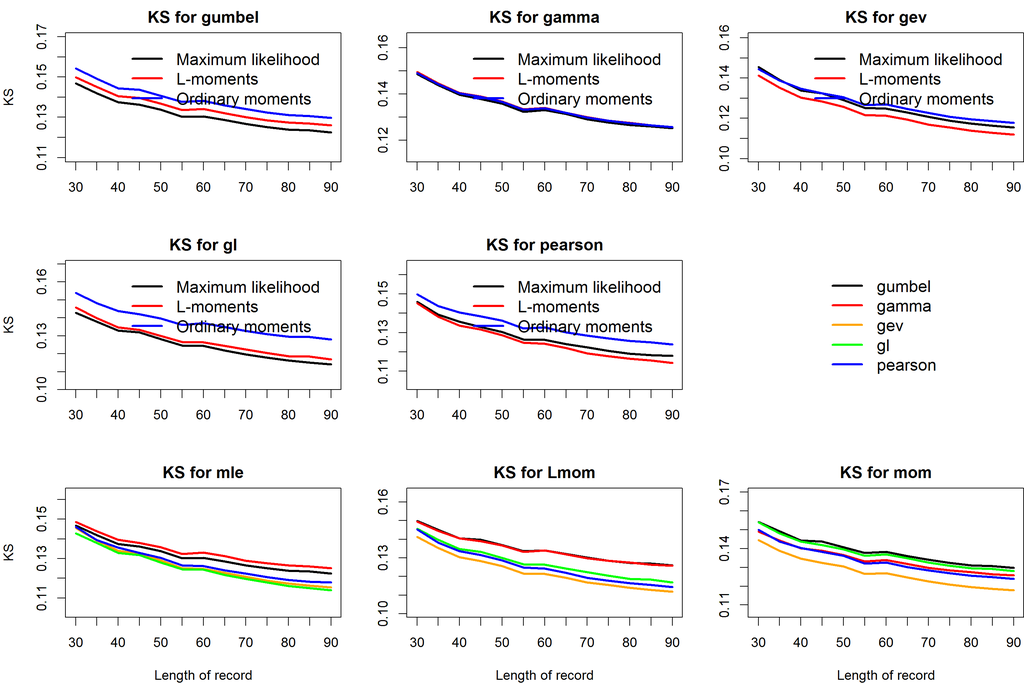

[1] 38 51 57 68 70 76 77 78 79 81 82 83 85 87 88 94 95 [18] 99 106 114 129 131 132 135 137 145 146 147 149 151 156 172 176 180 [35] 181 185 187 192 194 195 203 205 215 217 218 219 220 221 222 225 228 [52] 233 253 254 258 259 263 264 269 270 271 273 278 282 292 293 298 303 [69] 304 305 306 [1] “entered the plotting function” [1] 30 [1] 150

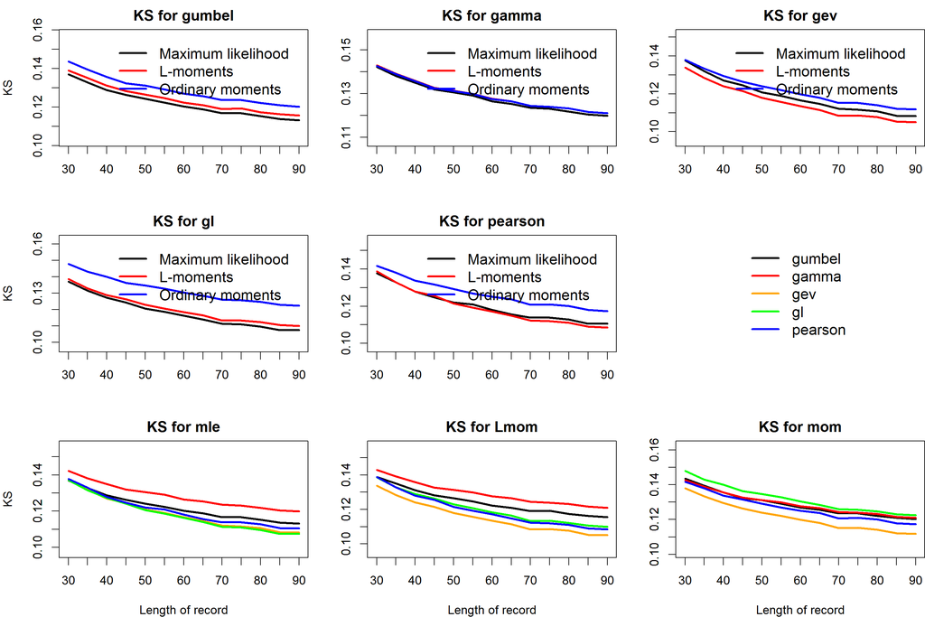

## AD

[1] 1 5 6 7 8 9 10 11 12 16 19 21 22 23 24 25 26 [18] 29 30 31 32 41 42 45 47 63 65 66 67 92 96 103 107 112 [35] 119 121 123 126 142 157 159 163 165 166 167 168 169 171 175 179 186 [52] 188 196 198 200 201 204 208 209 212 224 230 235 237 238 240 251 252 [69] 262 279 287 291 [1] “entered the plotting function” [1] 30 [1] 150

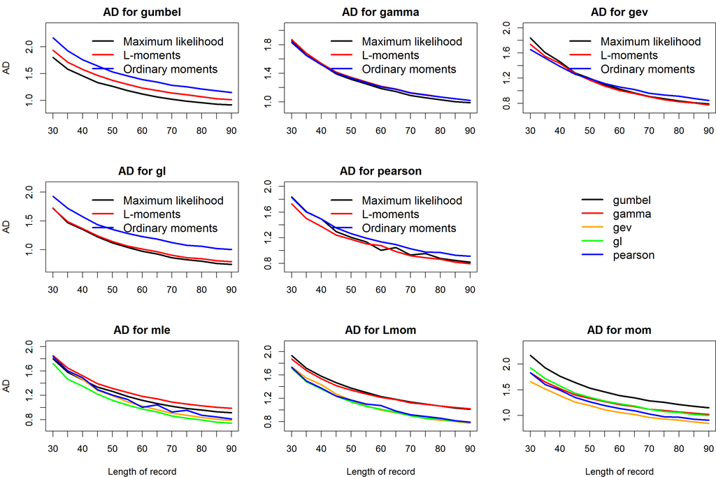

[1] 2 4 13 14 17 27 28 34 35 37 40 44 46 48 49 50 56 [18] 59 60 61 62 69 74 91 97 101 102 104 105 108 109 110 113 120 [35] 122 125 127 128 133 141 143 148 150 152 153 154 160 164 173 174 189 [52] 190 199 202 213 216 227 236 239 243 245 256 260 274 281 285 288 289 [69] 290 302 [1] “entered the plotting function” [1] 30 [1] 150

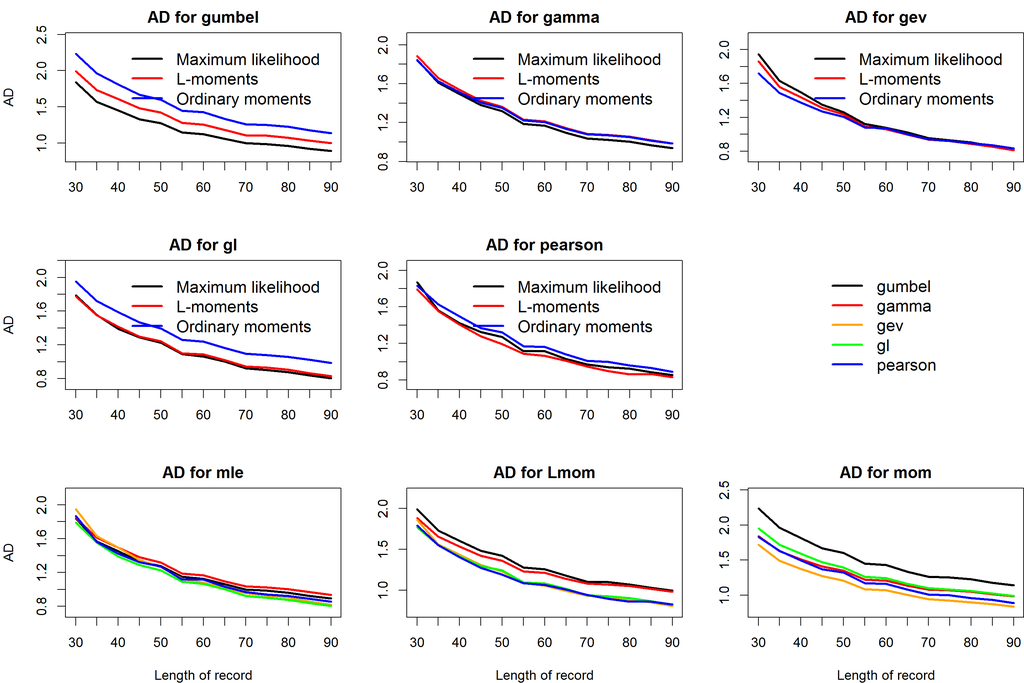

[1] 15 18 20 33 36 39 43 52 53 54 55 58 71 72 75 80 84 [18] 86 89 90 93 98 100 111 115 116 117 118 130 134 136 138 139 140 [35] 144 155 158 161 170 177 178 182 183 191 197 207 211 214 223 226 229 [52] 231 234 241 242 244 246 247 249 255 257 261 268 272 275 276 277 280 [69] 283 295 300 [1] “entered the plotting function” [1] 30 [1] 150

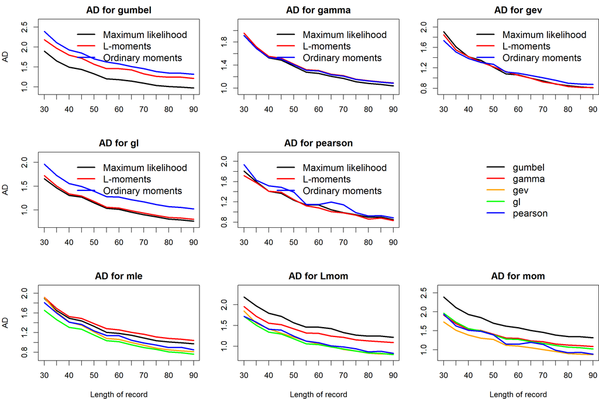

[1] 38 51 57 68 70 76 77 78 79 81 82 83 85 87 88 94 95 [18] 99 106 114 129 131 132 135 137 145 146 147 149 151 156 172 176 180 [35] 181 185 187 192 194 195 203 205 215 217 218 219 220 221 222 225 228 [52] 233 253 254 258 259 263 264 269 270 271 273 278 282 292 293 298 303 [69] 304 305 306 [1] “entered the plotting function” [1] 30 [1] 150

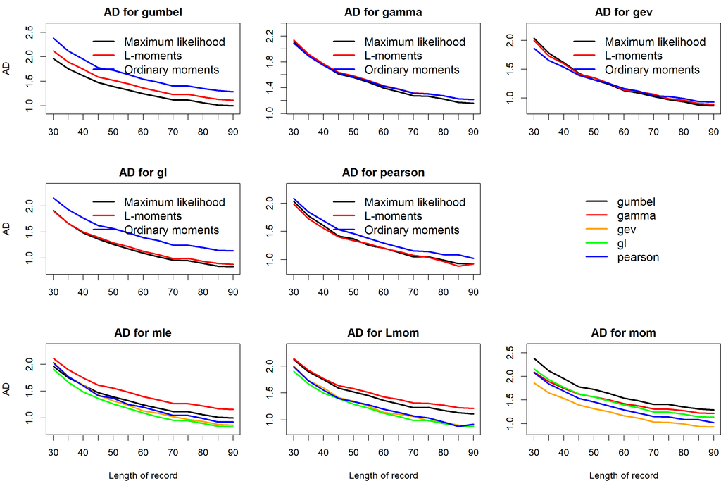